# STA 141 Final Project

Sai Suresh

5/3/2023

# Predicting Trial Outcome Using Neuronal Activity of Mice

# Abstract

In this project, we developed a model using the data from the Steinmetz et al. (2019) study to predict the trial outcome. Through exploration of the data set, we identified the `Trial`, `Mouse`, `Contrast Left` and `Contrast Right` interaction, `Average Spikes`, and `Average Root Spikes` to be the best predictors to use based on their apparent correlation with trial success (feedback = 1). Using these predictors and split-sample validation, we trained LDA, Logistic Regression, kNN, and Random Forest models to predict trial outcome. We evaluated these models based on three criteria: their accuracy rate misclassification rate, and F1 score. The accuracy rate represents the proportion of trials for which the model correctly predicted the feedback type. Conversely, the misclassfication rate is the proportion of trials for which the model incorrectly classified the feedback type. Lastly, the F1 score considers both false positives and false negatives to return a balanced evaluation of a model’s classifications. By these three criteria, the best performing model was the Random Forest model which included and interaction term between the contrasts and excluded the average spike count from the `root` brain area.

# Introduction

In this project, we will look at the data from the Steinmetz et al. (2019) study. In this study, the researchers presented visual stimuli to 10 different mice in 39 different sessions and had the mice make a decision using a wheel they could control with their feet.

Based on the decision of the mouse, the researchers would provide either a reward or a penalty. The visual stimuli varied in terms of contrast levels (0, 0.25, 0.5, or 1) and direction (left or right) recorded in the `contrast_left` and `contrast_right` variables. A successful trial is categorized by the mouse:

- Turning the wheel to the right when the left contrast > right contrast
- Turning the wheel to the left when the right contrast > left contrast
- Holding the wheel still when left contrast and right contrast are 0
- Random when left contrast = right contrast and non-zero

For each trial in each session, the feedback of the trial was recorded as a 1 if successful, and as -1 otherwise in the `feedback_type` column. Additionally, neuron activity of the mice was recorded in the form of spike trains, which captures a neuron firing at a certain time point in the 40 time bins recorded in `time`, which can be observed by the `spks` variable. If a neuron fired, a 1 in the respective time bin was recorded, and a 0 otherwise for each trial.

For this project, we will be focusing on session 1 to 18, which correspond to four mice: Cori, Frossman, Hence, and Lederberg. With this data, we will attempt to build a model that will be able to predict the outcome of a trial based on the available data. To accomplish this, we will first be exploring the data to find potential predictors and patterns within the sessions. Then, after identifying the variables we deem to be important, we will integrate the data across sessions and then develop and evaluate predictive models. Finally, we will use an additional test set we have not seen before to evaluate the performance of our optimal model.

# Exploratory Data Analysis

In order to get a better idea of the data set, I decided to make a table that summarizes information from each of the 18 sessions. I included the session number, mouse name, number of trials, number of neurons, the success rate, and the unique brain areas. I calculated the success rate by taking the average of the `feedback_type` variable across all the trials for each session, and then added 1 to account for the presence of -1s representing failures, and then dividing by 2 to get the correct rate of success.

```
## # A tibble: 6 × 6
##   Session Mouse     N.Trials N.Neurons Success.Rate Brain.Areas
##     <dbl> <chr>        <dbl>     <dbl>        <dbl> <chr>
## 1       1 Cori           114       734        0.605 ACA, MOs, LS, root, VISp, C…
## 2       2 Cori           251      1070        0.633 CA1, VISl, root, VISpm, POST
## 3       3 Cori           228       619        0.662 DG, VISam, MG, CA1, SPF, ro…
## 4       4 Forssmann      249      1769        0.667 LGd, DG, TH, SUB, VPL, VISp…
## 5       5 Forssmann      254      1077        0.661 VISa, root, CA1, SUB, DG, O…
## 6       6 Forssmann      290      1169        0.741 AUD, root, SSp, CA1, TH
```

I was interested in determining whether there was a relationship between the number of trials and the success rate for each mouse, so I decided to make a plot. I first grouped by the different mice, and then I summed the number of trials for each of them and averaged their success rates.

**Number of Trials and Success Rate**

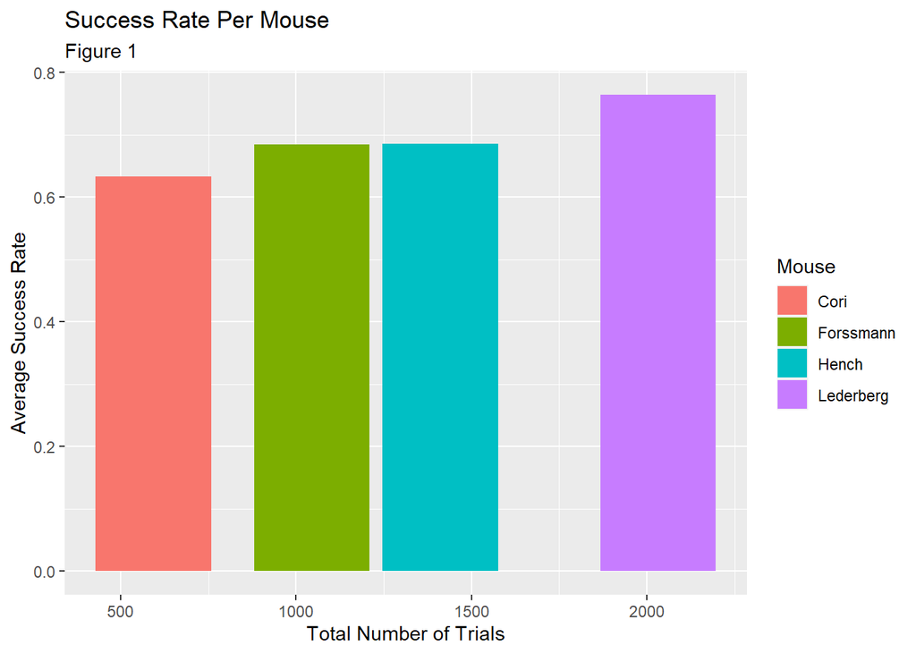

*Figure 1* suggests a correlation between the total number of trials and the average success rate. It appears that more trials correlates with a higher success rate. In fact, Lederberg had the most number of trials and the highest average success rate.

Next, I wanted to see the brain area breakdown for each mouse to see if there were any differences that potentially contributed to Lederberg’s greater average success rate. To do this, I observed the total count of spikes for each of the different brain areas over all the trials in all sessions for each mouse.

**Brain Area Distribution for Each Mouse**

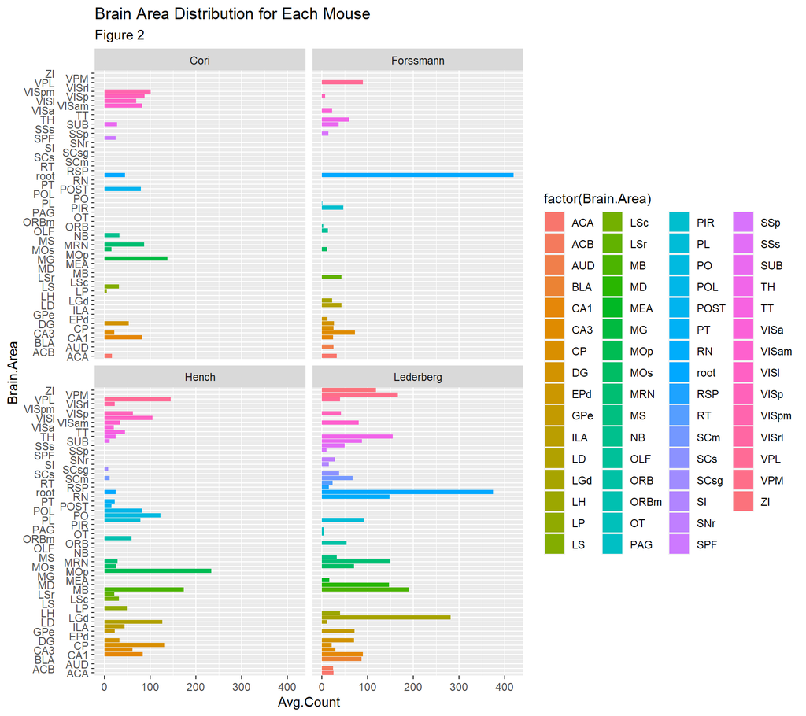

I would like to further investigate the success or failure of a trial could be partially attributable to the activity of a certain brain area. Although, prior to looking into this, I will first determine how many times each brain areas was observed in each session. Doing so will reveal the distribution of observed brain areas, allowing me to identify brain areas that are observed in a majority of sessions. Such brain areas could will help in connecting all the sessions together and their activity could also potentially be used as a predictor variable in the models.

**Brain Area Distribution for Each Session**

To see how many neurons from each brain area were observed in all the sessions, I summed the neurons coming from each brain area in each session and then plotted the results.

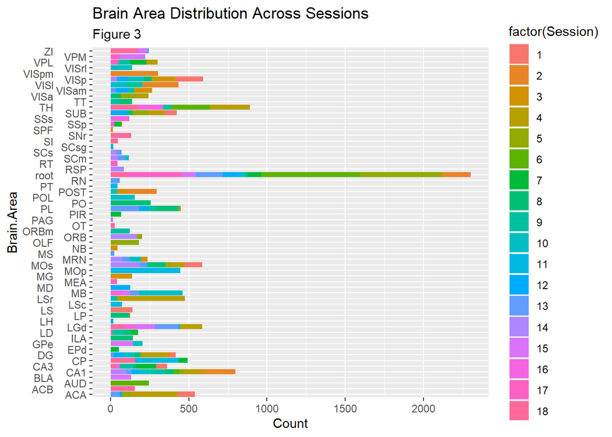

As seen in the *Figure 3*, there are not many brain areas that appear to have been counted in a majority of the sessions. Therefore, the difference in counts associated with a particular brain area could be due to the fact that the researchers did not look at neurons from that area, which hinders my ability to connect brain area counts to trial outcome. Although, one brain area that did get a high number of counts in a majority of sessions was the `root` brain area, so perhaps this is a good brain area to focus on instead of the `LGd` brain area mentioned from *Figure 2*.

I am interested in finding patterns that I can use to connect all the sessions together, therefore, I will not be investigating brain areas any further for the time being. Instead, based on *Figure 1*, I will select 4 sessions, one for each mouse, and investigate them to find other patterns in the data that I can then use to connect all the sessions. The sessions I will be focusing on for the next parts of the data exploration section are: *Sessions 2, 6, 9, and 17*.

First, I am interested in investigating whether or not the trial number of each session is related to the feedback outcome of the trial. For instance, maybe the earlier trials have more successes than later trials because the mice are more focused in the beginning of the session. Or, perhaps the mice are more successful in later trials because they are better trained. To observe the presence of any such relationship between trial and feedback outcome, I will initialize a summary table for these four sessions and begin by getting the session, trial, and feedback values for each trial in all the four sessions.

**Trial and Feedback Outcome**

To determine whether there is an association between the trial number and the outcome, I made a boxplot for each of the four sessions, as shown below.

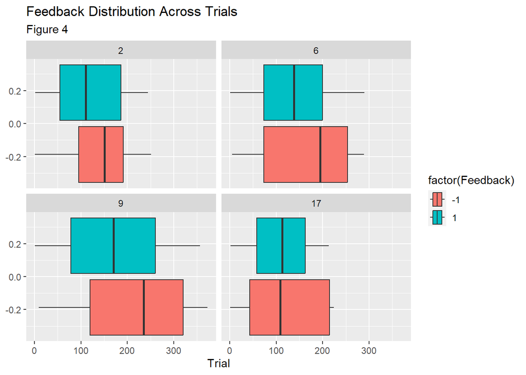

```
## # A tibble: 2 × 2
##   Feedback Avg.Trials
##      <dbl>      <dbl>
## 1       -1       174.
## 2        1       138.
```

Based on *Figure 4*, it appears that there are more successes in the earlier trials and more failures in the later trials. This supports my first hypothesis of the mice being more successful in earlier trials due to being more alert and focused.

Next, I am interested in determining whether there is an association between the `Contrast Left` and `Contrast Right` values and the feedback outcome of each trial.

**Relationship Between Contrast Values and Feedback**

To investigate this relationship, I will add the corresponding`Contrast Left` and `Contrast Right` values for each trial to my summary table. Then, I will graph the data and look for any patterns.

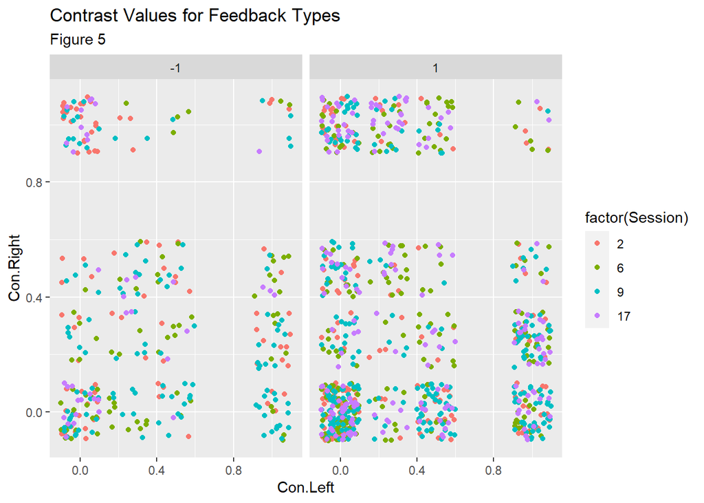

From *Figure 5*, we can see that there appear to be more successes when `Con.Left` is 1.0 and `Con.Right` is 0.0. Similarly, there are more successes when `Con.Left` is 0.0 and `Con.Right` is 1.0. Interestingly, there appears to be more unsuccessful trials along the diagonal, which corresponds to `Con.Left` and `Con.Right` values being identical. An exception to this is when `Con.Left` and `Con.Right` are both 0.0, as there appears to be more successes than failures attributed to trials in all sessions with these values. Based on these conclusions, I think an interaction term between `Con.Left` and `Con.Right` should be included in the predicted model.

Next, I am interested in looking at whether the number of active spikes and the success of a trial are related to each other. To investigate this, I will add the average active spike counts to the data table summarizing the four session and then visualize them in a graph.

**Investigate Relationship Between Spike Counts and Trial Outcome**

To observe the effects of average active spike count and trial outcome, I will create a new data table consisting of the session, trial, feedback, and average spikes and then plot them for each of the four sessions and see if there is any difference between the successful and unsuccessful trials.

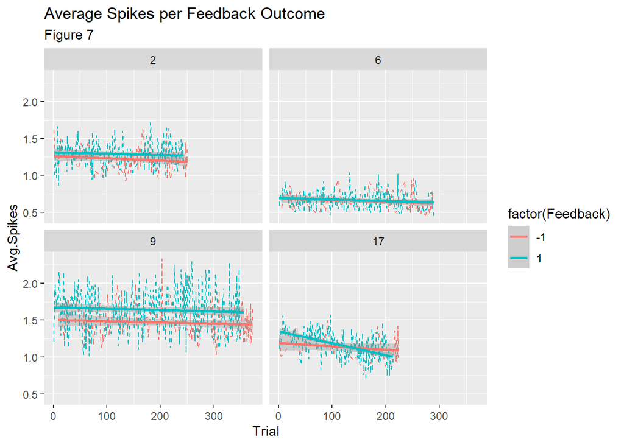

```
## # A tibble: 2 × 2
##   Feedback Avg.Spikes
##      <dbl>      <dbl>
## 1       -1       1.17
## 2        1       1.21
```

From *Figure 7*, we can observe that generally, successful trials (Feedback = 1) correlates with a greater value of average active spikes than in the unsuccessful trials (Feedback = -1). Thus, I think the average number of active spikes could be used as a predictor in a model as it appears to be associated with the outcome of a trial.

Now that I have found some predictors that connect all the sessions together, I will revisit my investigation of brain areas in these four sessions. I am interested in observing the activity of neurons over the trials from the various brain areas observed in these four sessions.

**Neuron Activity of Distinct Brain Areas Over Sessions**

To see if there is a relationship between the neuronal activity from different brain areas and trial outcome in these four sessions, I will plot the average spikes data from the four sessions summary table in the context of their brain area. To do this, I will first find all the unique brain areas present in the four selected sessions and make those into new individual columns. Then, for each brain area, I will sum the respective spikes and average them against the total number of spikes observed to calculate the average spike count for each brain area in each trial for the four sessions.

```
## [1] " Observed Brain Areas:"
```

```
##  [1] "CA1"   "VISl"  "root"  "VISpm" "POST"  "AUD"   "SSp"   "TH"    "TT"
## [10] "ORBm"  "PL"    "LSr"   "CA3"   "VISam" "VPL"   "LD"    "VPM"   "RT"
## [19] "MEA"
```

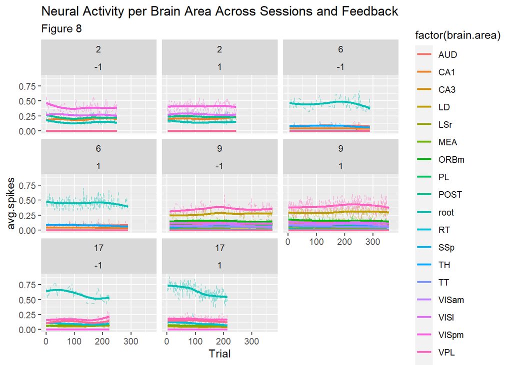

As shown in *Figure 8*, I plotted the various brain areas and their respective average spike count for sessions 2, 6, 9, and 17 and also faceted by feedback to see if I could identify any patterns within and between sessions. One observation from this plot is that the positive feedback trials appear to have a more stable, or constant, distribution for the brain areas measured. For instance, when comparing the negative and positive feedback trials of Session 2, the VISpm curve is horizontal, and thus, more constant in the successful trials than in the unsuccessful trials.

While the neuron activity over sessions within each brain area is interesting to observe, I do not think it is a good way to combine information over all sessions as it was determined earlier that the brain areas observed differed between sessions. Since different brain areas were observed in the sessions, some brain areas may not be able to be used when attempting to connect all sessions together. Therefore, to investigate the distribution of observed brain areas across all sessions, I summed I summed the number of spikes coming from each brain area across all trials for each session and then plotted the results.

To better understand how the average number of spikes varies between the successful and unsuccessful trials in each of the four sessions, I summarized the average spikes per brain area in each session for each feedback outcome.

```
## # A tibble: 8 × 21
## # Groups:   Session, Feedback [8]
##   Session Feedback   root    AUD    CA1   CA3     LD    LSr    MEA  ORBm     PL
##     <dbl>    <dbl>  <dbl>  <dbl>  <dbl> <dbl>  <dbl>  <dbl>  <dbl> <dbl>  <dbl>
## 1       2       -1 0.144  0      0.198  0     0      0      0      0     0
## 2       2        1 0.150  0      0.209  0     0      0      0      0     0
## 3       6       -1 0.445  0.0860 0.0418 0     0      0      0      0     0
## 4       6        1 0.453  0.0860 0.0427 0     0      0      0      0     0
## 5       9       -1 0.0115 0      0.106  0.130 0.272  0.0448 0      0.151 0.0815
## 6       9        1 0.0159 0      0.117  0.150 0.300  0.0482 0      0.162 0.0871
## 7      17       -1 0.590  0      0      0     0.0614 0      0.0732 0     0
## 8      17        1 0.636  0      0      0     0.0468 0      0.0686 0     0
## # ℹ 10 more variables: POST <dbl>, RT <dbl>, SSp <dbl>, TH <dbl>, TT <dbl>,
## #   VISam <dbl>, VISl <dbl>, VISpm <dbl>, VPL <dbl>, VPM <dbl>
```

From the table above, we can see that the only brain area we can really compare is the `root` brain area because it is present in all sessions. Looking at the root column, we can see that there is a slight increase in the average number of spikes corresponding to the `root` brain area in the successful trials.

```
## # A tibble: 2 × 2
##   Feedback Avg.Root
##      <dbl>    <dbl>
## 1       -1    0.298
## 2        1    0.314
```

```
## Session 4 does not observe the root brain area.
## Session 16 does not observe the root brain area.
```

```
## Session 4 observed brain areas: ACA CA1 DG LGd LSr MOs SUB TH VISa VISp VPL
```

```
## Session 16 observed brain areas: CA3 LGd MB SSp SSs TH
```

Although sessions 4 and 16 do not observe activity in the `root` brain area, they do both record activity of the “LGd” area, which looked interesting in *Figure 2*. So, I would like to see if the “LGd” brain area in sessions 4 and 16 are associated with the trial outcome.

```
## # A tibble: 6 × 3
##   Trial Feedback Avg.LGd
##   <dbl>    <dbl>   <dbl>
## 1     1        1  0.107
## 2     2        1  0.0882
## 3     3       -1  0.100
## 4     4        1  0.118
## 5     5        1  0.107
## 6     6       -1  0.123
```

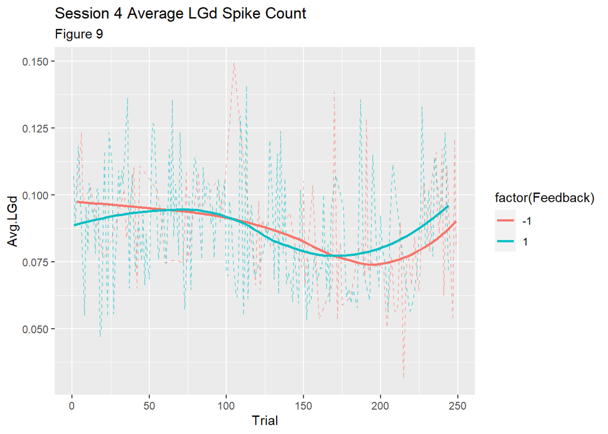

```
## # A tibble: 2 × 2
##   Feedback Avg.LGd
##      <dbl>   <dbl>
## 1       -1  0.0842
## 2        1  0.0874
```

```
## # A tibble: 6 × 3
##   Trial Feedback Avg.LGd
##   <dbl>    <dbl>   <dbl>
## 1     1        1   0.150
## 2     2        1   0.114
## 3     3       -1   0.124
## 4     4        1   0.108
## 5     5       -1   0.156
## 6     6        1   0.209
```

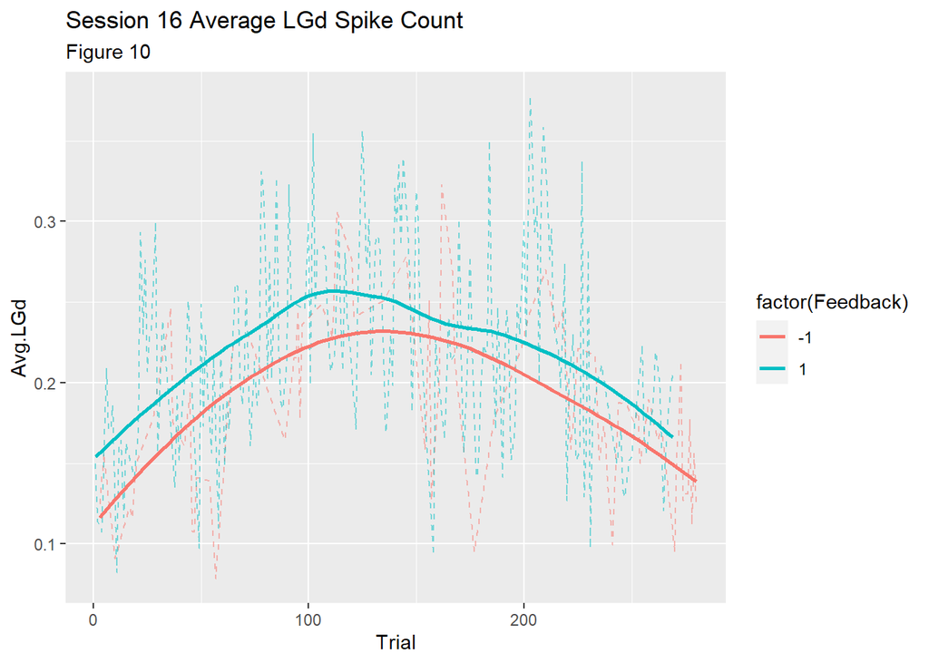

```
## # A tibble: 2 × 2
##   Feedback Avg.LGd
##      <dbl>   <dbl>
## 1       -1   0.181
## 2        1   0.221
```

As can be seen from *Figure 9* and *Figure 10*, the Average LGd Spike Count is higher in the successful trials than in the unsuccessful trials. However, the difference is more pronounced in session 16 than in session 4. Therefore, I decided against swapping the average root spikes value with the average LGd spikes value for these two sessions. Instead, I developed models without the average root spike count (including sessions 4 and 16) and models with the average root spike count (excluding sessions 4 and 16) and compared their performances in the model section.

Despite my hesitancy in using brain areas in my model due to them not being equally measured across all sessions, I wanted to look into which brain area had the most spike counts associated with it in each trial. My reasoning for doing so was that perhaps a specific brain area in each session led to the success of a trial when highly active. Thus, I made a new column in the summary table which includes the brain area associated with the highest spike count.

**Most Active Brain Area**

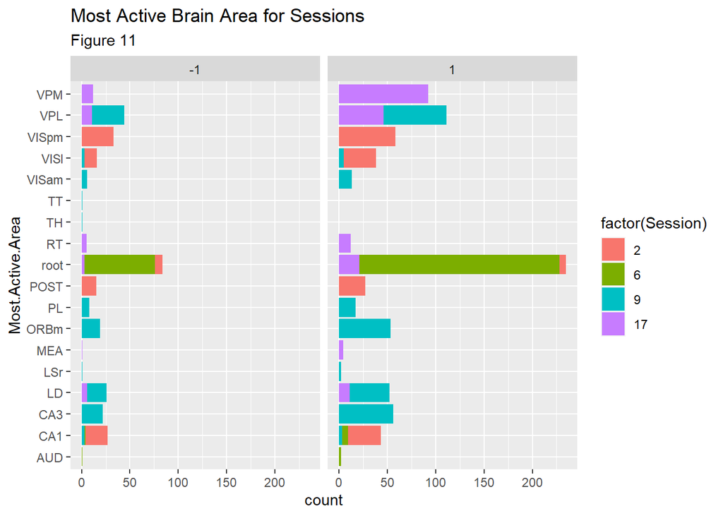

From *Figure 11*, there is not a clear, general pattern that can be applied to all four sessions; however, there is some insight gained. For instance,it appears that having `root` be the most active brain area in more trials is strongly associated with success in Session 6, and more weakly associated with success in Session 17.

Another observation is that in Session 17, successful trials have more counts of `VPM` being the most active brain area For Session 2, successful trials seem to have marginally more counts of `VISpm` and `VISI` being the most active brain areas.

Finally, successful trials in Session 9 appear to be associated with higher counts of `CA3` and `VPL` being the most active brain areas.

While these observed patterns are interesting, since the same brain areas are not observed across all sessions equally, it is difficult to use the most active brain area as a predictor for trial outcome. As mentioned above, when considering brain areas, I will focus only on the `root` brain area.

Pivoting away from the brain areas once again, I am interested in seeing if the maximum spike count associated with a single neuron shows a more clear association with trial outcome. For instance, perhaps having one highly active neuron is associated with trial success. Therefore, I will add another column consisting of the highest spike count for each trial and then plot it to observe any relationships.

**Association Between Maximum Spike Count and Trial Outcome**

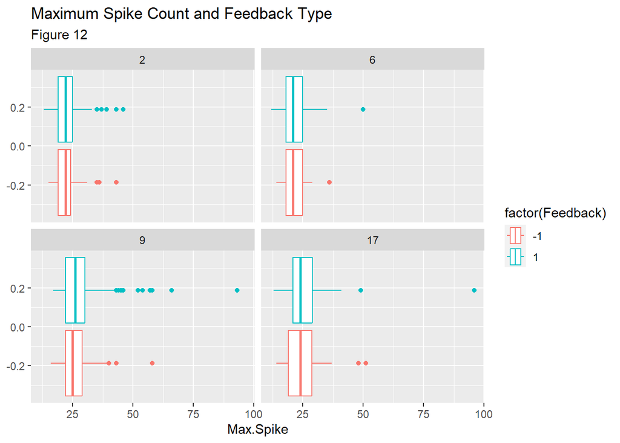

```
## # A tibble: 2 × 2
##   Feedback Avg.Max.Spike
##      <dbl>         <dbl>
## 1       -1          23.8
## 2        1          24.6
```

*Figure 12* shows the maximum spike count distribution appears to be nearly identical between the successful and unsuccessful trials This suggests that the high activity of a single neuron is not strongly associated with the trial outcome. Despite the maximum spike count not appearing to be a strong predictor, since there is a difference present between the successful and unsuccessful trials, I decided to use the maximum spike count as a predictor in my models.

Based on the various plots in this data exploration section, I will next compile the relevant variables across all sessions and trials in the Data Integration section. To recap, from my results, I anticipate that the `Mouse`, `Contrast Left`, `Contrast Right`, `Average Number of Spikes`, `Trial`, and `Maximum Spike Count` will serve as good predictors for trial outcome based on the patterns I have observed above across all sessions.

I will also add the `Average Root Spike Count` as a predictor in some models and compare between those that utilize this predictor and those that do not as this variable will force me to disregard some data and I want to be sure that doing so improves my model’s ability to accurately predict the trial outcomes.

# Data Integration

## Gather Relevant Information Across All Sessions and Trials

Now that I have found the variables I believe to be important in predicting trial outcome, I will create a new data table consisting of these relevant variables across all trials in all sessions. For the first models, I will not integrate the average spike count from the `root` brain area.

```
## # A tibble: 6 × 8
##   Session Trial Mouse Con.L Con.R Feedback Avg.Spikes Max.Spike
##     <dbl> <dbl> <chr> <dbl> <dbl>    <dbl>      <dbl>     <dbl>
## 1       1     1 Cori    0     0.5        1       1.58        24
## 2       1     2 Cori    0     0          1       1.31        25
## 3       1     3 Cori    0.5   1         -1       1.84        31
## 4       1     4 Cori    0     0         -1       1.38        30
## 5       1     5 Cori    0     0         -1       1.43        37
## 6       1     6 Cori    0     0          1       1.09        35
```

# Building the Model

Now that I have integrated the relevant information across all sessions and trials into one data table, I can begin building and evaluating prediction models. In this section, I will build a variety of different models and compare their performances to decide upon the optimal model for predicting trial outcome. First, I will split my data into a training and testing sets so that I am able to avoid over-fitting my models and evaluate their prediction accuracy against the test set.

## Split-Sample Preparation

I will split my integrated data set into a training and testing set so that I can build and evaluate the performance of my prediction models. Before splitting my data, I first changed the `Feedback` column into a factor with levels 0 and 1, for unsuccessful and successful trials, respectively. Then, I also scaled my data so that it is normalized.

```
## [1] "Training Set:"
```

```
## # A tibble: 6 × 8
##   Session Trial Mouse     Con.L Con.R Feedback Avg.Spikes Max.Spike
##     <dbl> <dbl> <chr>     <dbl> <dbl> <fct>         <dbl>     <dbl>
## 1      18   156 Lederberg  0.25   1   1            -0.402     0.195
## 2      16   191 Lederberg  0.5    0   1            -1.04     -1.62
## 3      12   144 Lederberg  0.25   1   1             0.713    -0.753
## 4      18   144 Lederberg  0.5    0   1            -0.714     1.38
## 5       5   173 Forssmann  0      0   1            -0.806     0.511
## 6      15   288 Lederberg  0.5    0.5 1             0.179    -0.279
```

```
## [1] "Testing Set:"
```

```
## # A tibble: 6 × 8
##   Session Trial Mouse Con.L Con.R Feedback Avg.Spikes Max.Spike
##     <dbl> <dbl> <chr> <dbl> <dbl> <fct>         <dbl>     <dbl>
## 1       1     2 Cori      0     0 1           -0.119     -0.674
## 2       1     9 Cori      0     0 1            0.282      1.62
## 3       1    12 Cori      0     1 1            1.08      -0.437
## 4       1    13 Cori      1     1 0            0.799     -0.516
## 5       1    14 Cori      0     0 0            0.180     -1.07
## 6       1    17 Cori      0     0 1           -0.0137    -0.516
```

Now that my data has been integrated across all sessions and trials, I will begin building and evaluating models based on their ability to accurately predict the trial outcomes. I will be evaluating the performance of various models based on three model metrics described below, which will then allow me to compare the performance of all the models and help me select the best one.

## Model Metrics

The metrics I will use to evaluate the performance of my model are:

1. Accuracy Rate: the percentage of trials in which the model correctly predicts the feedback type of the trial
2. Misclassification Rate: the percentage of trials in which the model incorrectly classifies a trial’s outcome.
3. F-1 Score: considers the false positives and false negatives by combining the precision and recall rates
- Precision: the proportion of cases correctly classified as positive out of all cases predicted as positive
- Recall: the proportion of cases correctly classified as positive out of all actual positive cases

Now that I have defined the measurements by which I will be evaluating the performance of the predictive models, I will define a benchmark model against which I can compare my other models against to ensure they have improved their accuracy in making trial outcome predictions.

## Benchmark Models

For the benchmark models, I will only be using only the trial number as a predictor as this was a variable given to us in the data set. I decided on using a LDA model and a Random Forest model for my two benchmark models as they are two different classification methods with different levels of complexity. LDA looks at linear combinations to classify the data whereas Random Forest uses multiple decision trees to classify the data, making it more intensive than LDA. By including a more simple LDA model and a more complex Random Forest model for my benchmark models, I am able to better assess whether my choice of additional predictors actually improves the classification ability of the models.

As I build my models, I will be inputting the results of the evaluation criteria mentioned above into a summary table, which I will then use to decide upon the optimal predictive model. For each model I will print the accuracy rate just to get a quick idea of how the model performs. The other evaluation criteria will be viewable in the summary table of all fitted models.

### Benchmark - LDA

```
## [1] "Benchmark LDA:"
```

```
## Accuracy: 70.36066
```

### Benchmark Random Forest

```
## [1] "Benchmark Random Forest:"
```

```
## Model Accuracy: 67.27869
```

With the benchmark models defined, I can create models with the additional predictors: `Session`, `Trial`, `Mouse`, `Con.L`, `Con.R`, `Avg.Spikes`, `Max.Spike`, and the interaction term of `Con.L*Con.R`.

I then evaluate their performance, and compare them to the benchmark model. The first model I fit to the data was a Linear Discriminant Analysis model.

## Linear Discriminant Analysis Model - Without Average Root Spike Count

```
## [1] "LDA without Interaction or Root Spike:"
```

```
## Model Accuracy: 70.81967
```

In the LDA model above, I used the `Mouse`, `Trial`, `Avg.Spikes`, `Con.L`, and `Con.R` predictors in my model based on the visualizations comparing these values between the successful and unsuccessful trials above. I found that omitting the `Con.L:Con.R` interaction term actually increased my model’s accuracy, so I left it out.

Next, I want to see if a logistical regression model may produce a more accurate model, so I will fit and evaluate one next.

## Logistic Regression Model - Without Average Root Spike Count

```
## [1] "Logistic Regression without Interaction or Root Spike:"
```

```
## Model Accuracy: 70.68852
```

I built a logistical regression model using `Session`, `Mouse`, `Trial`, `Avg.Spikes`,`Max.Spike`, and the `Con.L` and `Con.R` variables as predictors. Here also, I found that omitting the `Con.L:Con.R` interaction term produced a more accurate model, so I dropped this term from the model.

This model has an accuracy a misclassification rate of very similar to that of the LDA model. Next, I want to try a k Nearest Neighbors (kNN) classification model to see if this is better at predicting the trial outcome.

## kNN Model - Without Average Root Spike Count

Before fitting my kNN model, I first found the optimal k using a cross-validation approach of fitting various values of k and choosing the one that minimized the misclassifaction rate.

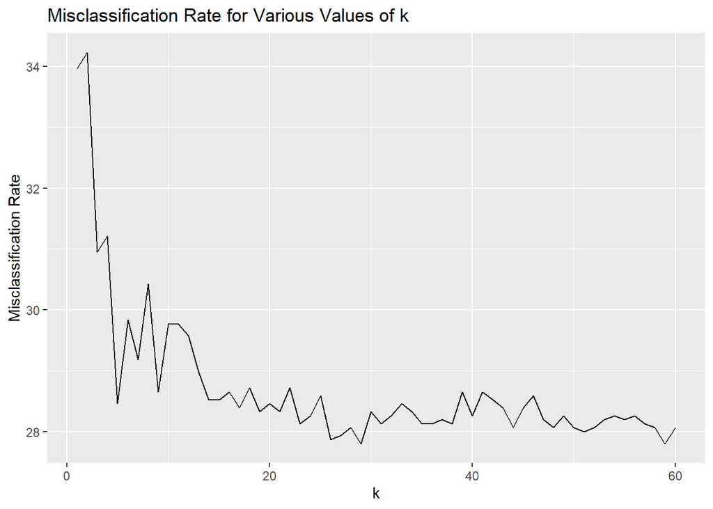

```
## Optimal k: 29
```

```
## [1] "kNN without Root Spike:"
```

```
## Model Accuracy: 72.19672
```

In order to fit the kNN model, I omitted the `Mouse` and `Feedback` columns of the training and testing sets as the `Mouse` variable was not a factor and the `Feedback` is what we are predicting. I also did not use the interaction term `Con.L:Con.R` for this model.

The kNN model appears to perform better than the LDA and Logistic Regression models. I will also fit a Random Forest model to see if this provides an even greater accuracy rate.

## Random Forest Without Average Root Spike Count

```r
# acknowledgements 9
rf.mod <- randomForest(Feedback ~. +Con.L*Con.R, data=train.data, importance=TRUE)

# predict, acknowledgements 3
predict.rf <- predict(rf.mod, newdata=test.data, type="response")

# confusion matrix
cm <- table(predict.rf, test.data$Feedback)
#cm

# model metrics
me = misclass.rate(cm)
acc = accuracy.rate(cm)
f1 = F1(cm)
print("Random Forest, without Root Spike:")
```

```
## [1] "Random Forest, without Root Spike:"
```

```r
cat("Model Accuracy:", acc)
```

```
## Model Accuracy: 75.08197
```

```r
# add to summary table, acknowledgements 5
model.sum <- model.sum %>% add_row(Model="Random Forest, with interaction, without root", Accuracy=acc,
                                   Misclassfication.Rate=me, F1.Score=f1)
```

For the Random Forest model, I found that the accuracy was improved with the addition of the `Con.L:Con.R` interaction term, so I included it in this model.

```
## # A tibble: 6 × 4
##   Model                                  Accuracy Misclassfication.Rate F1.Score
##   <chr>                                     <dbl>                 <dbl>    <dbl>
## 1 Benchmark LDA                              70.4                  29.6    0.826
## 2 Benchmark Random Forest                    67.3                  32.7    0.796
## 3 LDA, no interaction or root                70.8                  29.2    0.827
## 4 Logistic Regression, no interaction o…     70.7                  29.3    0.826
## 5 kNN, no root                               72.2                  27.8    0.831
## 6 Random Forest, with interaction, with…     75.1                  24.9    0.841
```

Looking at the model metrics for all the models we have fitted so far, it appears that the Random Forest model has the best performance.However, I want to try re-fitting all of these models with an additional predictor of `Avg.Root` which represents the average spike activity from the `root` brain area. In the data exploration section, I observed a slight difference between the negative and positive feedback types in the four summary sessions, thus, it may help improve the accuracy of the models. I observed this was a brain area observed in all sessions except for 4 and 16, so I will have to omit the data from these sessions.

To include the `Avg.Root` spike count in my models, I will add a column to my data table which corresponds to the average spike count from the `root` brain area from each trial. Then, I will remove the NAs that will arise from sessions 4 and 16, scale the data, split it into the training and testing sets, and then re-fit and evaluate the resulting models.

```
## # A tibble: 6 × 9
##   Session Trial Mouse Con.L Con.R Feedback Avg.Spikes Max.Spike Avg.Root
##     <dbl> <dbl> <chr> <dbl> <dbl> <fct>         <dbl>     <dbl>    <dbl>
## 1       1     1 Cori    0     0.5 1            0.428     -0.753   0.0123
## 2       1     2 Cori    0     0   1           -0.119     -0.674   0.0163
## 3       1     3 Cori    0.5   1   0            0.962     -0.200   0.0354
## 4       1     4 Cori    0     0   0            0.0222    -0.279   0.0259
## 5       1     5 Cori    0     0   0            0.111      0.274   0.0191
## 6       1     6 Cori    0     0   1           -0.561      0.116   0.0150
```

Now that I have added the average root spike count for each trial, I can remove the data with NAs in this column (Sessions 4 and 16), and then scale the data in the column. Once I have completed these pre-processing steps, I can then split the data into the training and testing sets.

```
## [1] "Training Set:"
```

```
## # A tibble: 6 × 9
##   Session Trial Mouse     Con.L Con.R Feedback Avg.Spikes Max.Spike Avg.Root
##     <dbl> <dbl> <chr>     <dbl> <dbl> <fct>         <dbl>     <dbl>    <dbl>
## 1      18   216 Lederberg  0     1    0            -0.774    0.589   -0.241
## 2      13    53 Lederberg  0.25  0    1             1.87     0.747    0.310
## 3       6   168 Forssmann  0.25  1    1            -1.62    -0.832    0.801
## 4      17   133 Lederberg  0.5   0    1            -0.597   -1.38     1.87
## 5       6    89 Forssmann  0     0.25 1            -1.46    -1.38     0.974
## 6       7    51 Forssmann  0     0    0            -0.786   -0.0422   0.0234
```

```
## [1] "Testing Set:"
```

```
## # A tibble: 6 × 9
##   Session Trial Mouse Con.L Con.R Feedback Avg.Spikes Max.Spike Avg.Root
##     <dbl> <dbl> <chr> <dbl> <dbl> <fct>         <dbl>     <dbl>    <dbl>
## 1       1     2 Cori   0      0   1           -0.119     -0.674   -0.727
## 2       1    14 Cori   0      0   0            0.180     -1.07    -0.693
## 3       1    17 Cori   0      0   1           -0.0137    -0.516   -0.715
## 4       1    20 Cori   0.25   1   1            1.49      -0.753   -0.658
## 5       1    22 Cori   1      0.5 0           -0.232     -0.753   -0.750
## 6       1    24 Cori   0      0   1            0.459      0.274   -0.687
```

Next, I can re-build my models from above with the average root spikes variable as an additional predictor and compare the accuracy rates to see if the average root spike count improves the models’ ability to predict trial outcome.

## Linear Discriminant Analysis - With Average Root Spike Count

```
## [1] "LDA with Root Spike:"
```

```
## Model Accuracy: 71.01025
```

To accurately compare the addition of the `Avg.Root` predictor to the models, I have omitted the `Con.L:Con.R` interaction term from the LDA model.

## Logistic Regression Model - With Average Root Spike Count

```
## [1] "Logistic Regression, with Root Spike:"
```

```
## Model Accuracy: 70.79063
```

I also omitted the `Con.L:Con.R` interaction term from this logistic regression model including the `Avg.Root` as a predictor since I found that the interaction term did not help the model’s accuracy in the earlier logistic regression model without the `Avg.Root` predictor.

## kNN Model - With Average Root Spike Count

I first used cross validation to determine the optimal value for k. To do this, I used the function I created before my previous kNN model using the training and testing sets that include the average root spike count.

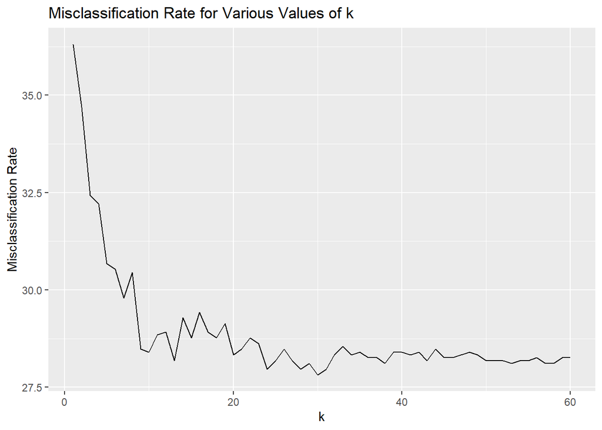

```
## Optimal k: 30
```

```
## [1] "kNN with Root Spike:"
```

```
## Model Accuracy: 72.10835
```

## Random Forest Model - With Average Root Spike Count

```
## [1] "Random Forest, with Root Spike:"
```

```
## Model Accuracy: 75.0366
```

For the random forest model with `Avg.Root` as a predictor, I included the `Con.L*Con.R` interaction term since I included it for the earlier Random Forest model which did not consider the `Avg.Root` as a predictor.

One last model I want to consider is the decision tree model. However, since its approach is slightly similar to a Random Forest, which uses a collection of decision trees, I will only fit one model for it with the `Avg.Root` as added predictors. However, I could not use the interaction term `Con.L:Con.R` in this model so I omitted it. In doing this, I want to evaluate how much more effective the Random Forest algorithm is compared to a single Decision Tree algorithm in classifying the data accurately.

## Decision Tree - With Average Root Spike Count

```
## [1] "Decision Tree with Root Spike:"
```

```
## Model Accuracy: 72.10835
```

Now that I have fit various models, it is time to look at the summary table containing all the model metrics for each model and decide upon the best predictive model for this data set.

# Results

| Model | Accuracy | Misclassfication.Rate | F1.Score |
| --- | --- | --- | --- |
| Benchmark LDA | 70.361 | 29.639 | 0.826 |
| Benchmark Random Forest | 67.279 | 32.721 | 0.796 |
| LDA, no interaction or root | 70.820 | 29.180 | 0.827 |
| Logistic Regression, no interaction or root | 70.689 | 29.311 | 0.826 |
| kNN, no root | 72.197 | 27.803 | 0.831 |
| Random Forest, with interaction, without root | 75.082 | 24.918 | 0.841 |
| LDA, with root | 71.010 | 28.990 | 0.828 |
| Logistic Regression, with root | 70.791 | 29.209 | 0.827 |
| kNN, with root | 72.108 | 27.892 | 0.831 |
| Random Forest, with interaction and root | 75.037 | 24.963 | 0.841 |
| Decision Tree, no interaction with root | 72.108 | 27.892 | 0.826 |

Looking at this summary table, the Random Forest model with the interaction term `Con.L:Con.R` and without the `Avg.Root` included as a predictor appears to have the best performance based on its high accuracy rate, low misclassification rate, and greatest F-1 score out of all the fitted models.

In summary, the Random Forest model with interaction and no root is the optimal model for classifying the feedback trial of types. This model utilized `Session`, `Mouse`, `Trial`, `Con.L`, `Con.R`, the interaction term `Con.L:Con.R`, `Avg.Spikes`, and `Max.Spike` as predictors. Since the `Avg.Root` was omitted as a predictor, the data from all sessions was able to be used to train and test the model.

Next, I will evaluate this model against the test data sourced from Sessions 1 and 18.

## Evaluate Optimal Model Against Test Data

```
## # A tibble: 6 × 8
##   Session Trial Mouse Con.L Con.R Feedback Avg.Spikes Max.Spike
##     <dbl> <dbl> <chr> <dbl> <dbl> <fct>         <dbl>     <dbl>
## 1       1     1 Cori   0.25  0.25 0             0.430    -0.636
## 2       1     2 Cori   0     0    1             0.810     0.421
## 3       1     3 Cori   1     0.5  1             1.83     -0.460
## 4       1     4 Cori   0     0.5  1             1.66     -0.548
## 5       1     5 Cori   1     0.5  1             0.907    -0.284
## 6       1     6 Cori   0.5   0.25 1             0.232    -1.17
```

After reading in the test data and extracting all of the relevant information needed for my optimal Random Forest with interaction, no root model, I can use the model to predict the trial outcome for these test trials.

```
##
## predict.test   0   1
##            0  10   8
##            1  45 137
```

```
## Model Accuracy: 73.5 %
```

| Accuracy | Misclassification.Rate | F1.Score |
| --- | --- | --- |
| 73.5 | 26.5 | 0.838 |

The Random Forest, with interaction and no root model was fairly accurate in predicting the feedback type of each trial. The accuracy percentage means that for 73.5% of trials, the model correctly classified the feedback type of the trial. Consequently, the misclassification rate of 26.5% tells us that 26.5% of trials were classified as the incorrect feedback type. Lastly, the F-1 score represents a combination of precision and recall metrics. Thus, the higher the F-1 score, the higher the precision and recall of the model is. Once again, the precision represents the proportion of cases correctly classified as positive out of all cases classified as positive whereas the recall represents all correctly classified positive cases out of all actual positive cases. Thus, the higher the F-1 score, the better the model.

From the confusion matrix, we can observe that the model seemed to have a more difficult time in classifying the unsuccessful trials as it predicted more of the actual unsuccessful trials as successful than it classified the actual successful trials as unsuccessful. This may be due to the fact that a many of the trials were actually successes. Therefore, the bias towards successful trials made it difficult to train the model to accurately predict the unsuccessful trials as there was less data for it to train these classifications off of.

# Acknowledgements

- Collaborated with Claire Hsieh, who is also in this class to help in brainstorming ideas and helping each other with some code errors throughout the project.
1. [LDA](https://rpubs.com/pranaugi011089/98288)
2. [Jitter Points in ggplot](https://ggplot2.tidyverse.org/reference/geom_jitter.html)
3. [Predict Function in R](https://www.digitalocean.com/community/tutorials/predict-function-in-r)
4. [Find Index of Max in Matrix](https://stackoverflow.com/questions/743622/finding-row-index-containing-maximum-value-using-r)
5. [Add Row to Tibble](https://stackoverflow.com/questions/67531377/inserting-a-new-row-without-specifying-column-names-in-r-using-dplyr)
6. [Fix Overlapping ggplot Labels](https://datavizpyr.com/how-to-dodge-overlapping-text-on-x-axis-labels-in-ggplot2/)
7. [Sort Data Frame](https://www.statology.org/sort-dataframe-by-column-in-r/)
8. [Add Column to Tibble](https://stackoverflow.com/questions/54693682/how-to-add-multiple-columns-to-a-tibble)
9. [Random Forest](https://www.r-bloggers.com/2021/04/random-forest-in-r/)
10. [Models Summary Table](https://bookdown.org/yihui/rmarkdown-cookbook/kable.html)
11. [Table of Contents in R Markdown](https://bookdown.org/yihui/rmarkdown/html-document.html)
12. [Choose Optimal k for kNN](https://medium.com/@moussadoumbia_90919/elbow-method-in-supervised-learning-optimal-k-value-99d425f229e7)
13. [Return More than 1 Value in Function](https://stackoverflow.com/questions/19622028/return-plot-from-r-function)
14. Class Discussion week 8 materials for model metrics

# Code Appendix

```r
knitr::opts_chunk$set(echo = TRUE)
suppressWarnings(library(tidyverse))
suppressWarnings(library(knitr))
setwd("~/College Semesters/Spring 2023/STA 141A/Project/") # set working directory
# Load in data
sessions=list()

for(i in 1:18){
  sessions[[i]]=readRDS(paste('./Data/session',i,'.rds', sep=''))
}

data <- tibble(Session=as.numeric(), Mouse=as.character(), N.Trials=as.numeric(), N.Neurons=as.numeric(),
               Success.Rate=as.numeric(), Brain.Areas=as.character())
for (i in 1:18) {

  num_trials = length(sessions[[i]]$time)
  num_neurons = nrow(sessions[[i]]$spks[[1]])
  mouse_name = sessions[[i]]$mouse_name
  success_rate = mean(sessions[[i]]$feedback_type + 1)/2
  brain_areas = c(unique(sessions[[i]]$brain_area)) %>% toString()

  # round success rate to 3 significant digits
  success_rate = format(round(success_rate, digits=3)) %>% as.numeric()

  # add row, acknowledgements 5
  data <- data %>% add_row(Session=i, Mouse=mouse_name, N.Trials=num_trials, N.Neurons=num_neurons,
               Success.Rate=success_rate, Brain.Areas=brain_areas)
}
# check
head(data)
data %>% group_by(`Mouse`) %>%
  summarize(tot_trials=sum(`N.Trials`),
            avg_success=mean(`Success.Rate`)) %>%
  ggplot(aes(fill=`Mouse`)) +
  geom_col(mapping=aes(x=tot_trials, y=avg_success)) +
  xlab("Total Number of Trials") +
  ylab("Average Success Rate") +
  ggtitle(label="Success Rate Per Mouse", subtitle="Figure 1")


# get total number of unique brain areas across all sessions
brain.areas <- c()
for (i in 1:18){
  unique.areas <- unique(sessions[[i]]$brain_area)
  for (j in 1:length(unique.areas)){
    if (unique.areas[j] %in% brain.areas) {
      next
    }
    else {
      brain.areas <- append(unique.areas[j], brain.areas)
    }
  }
}
brain.areas <- sort(brain.areas) # sort alphabetically, acknowledgements 7

# summed spike matrix for each session
sum.session.spikes <- function(sid) {
  n.trial = sessions[[sid]]$feedback_type %>% length()
   for(i in 1:n.trial) {
     if (i == 1) {
       session.spk.matrix = apply(sessions[[sid]]$spks[[1]], 1, sum)
     }
     else {
       session.spk.matrix = session.spk.matrix + apply(sessions[[sid]]$spks[[i]], 1, sum)
     }
   }
  return (session.spk.matrix)
}


# data frame with counts of spikes corresponding to each brain area for each session
sessions.brain.areas.counts <- tibble("Session"=as.numeric(), "Mouse"=as.character(),"Brain.Area"=as.character(),
                                      "Avg.Count"=as.numeric())
for (i in 1:18){
  session.id = i
  mouse = sessions[[i]]$mouse_name
  sum.spikes = sum.session.spikes(i)
  for (j in 1:length(brain.areas)){
    ba = brain.areas[j]
    ba.index = which(sessions[[i]]$brain_area == ba)
    count = sum.spikes[ba.index] %>% sum()
    avg.count = count/length(sum.spikes)
    sessions.brain.areas.counts <- sessions.brain.areas.counts %>%
      add_row(Session=session.id, Mouse=mouse, Brain.Area=ba, Avg.Count=avg.count) # acknowledgements 5
  }
}

# plot brain areas counts across all sessions

sessions.brain.areas.counts %>% ggplot() +
  geom_col(mapping=aes(x=Brain.Area, y=Avg.Count, fill=factor(Brain.Area))) +
  facet_wrap(facets=vars(Mouse)) +
  scale_x_discrete(guide = guide_axis(n.dodge = 2)) + # acknowledgements 6
  scale_y_continuous(guide=guide_axis(n.dodge = 1)) + # acknowledgements 6
  coord_flip() +
  ggtitle(label="Brain Area Distribution for Each Mouse", subtitle="Figure 2")

sessions.brain.areas.obs <- tibble("Session"=as.numeric(), "Mouse"=as.character(),"Brain.Area"=as.character(),
                                      "Count"=as.numeric())
for (i in 1:18){
  session.id = i
  mouse = sessions[[i]]$mouse_name
  for (j in 1:length(brain.areas)){
    ba = brain.areas[j]
    ba.index = which(sessions[[i]]$brain_area == ba)
    count = ba.index %>% length() # how many spikes from each area observed
    sessions.brain.areas.obs <- sessions.brain.areas.obs %>%
      add_row(Session=session.id, Mouse=mouse, Brain.Area=ba, Count=count) # acknowledgements 5
  }
}


sessions.brain.areas.obs %>% ggplot() +
  geom_col(mapping=aes(x=Brain.Area, y=Count, fill=factor(Session))) +
  scale_x_discrete(guide = guide_axis(n.dodge = 2)) + # acknowledgements 6
  scale_y_continuous(guide=guide_axis(n.dodge = 1)) + # acknowledgements 6
  coord_flip() +
  ggtitle(label="Brain Area Distribution Across Sessions", subtitle="Figure 3")
sessions.summary <- tibble("Session"=as.numeric(), "Trial"=as.numeric(), "Mouse"=as.character(), "Feedback"=as.numeric())

for (i in c(2, 6, 9, 17)) {
  mouse = sessions[[i]]$mouse_name
  for (j in 1:nrow(sessions[[i]]$feedback_type)) {
    fb = sessions[[i]]$feedback_type[j]

    # add row to tibble, acknowledgements 5
    sessions.summary <- sessions.summary %>% add_row(Session=i, Trial=j, Mouse=mouse, `Feedback`=fb)
  }
}
#head(sessions.summary)

# plot trial and feedback
sessions.summary %>% ggplot() +
  geom_boxplot(aes(x=Trial, fill=factor(Feedback))) +
  facet_wrap(facets=vars(Session)) +
  ggtitle("Feedback Distribution Across Trials", subtitle="Figure 4")

# get mean number of trials
sessions.summary %>% group_by(Feedback) %>% summarize(Avg.Trials=mean(Trial))
# add new columns
sessions.summary$`Con.Left` <- rep(0,nrow(sessions.summary))
sessions.summary$`Con.Right` <- rep(0, nrow(sessions.summary))


for (i in 1:nrow(sessions.summary)){
  s.i = sessions.summary[i,]$Session
  t.i = sessions.summary[i,]$Trial
  con.left = sessions[[s.i]]$contrast_left[[t.i]]
  con.right = sessions[[s.i]]$contrast_right[[t.i]]

  # add to summary tibble
  sessions.summary$Con.Left[i] <- con.left
  sessions.summary$Con.Right[i] <- con.right
}

# acknowledgements 2
# plot
sessions.summary %>% ggplot() +
  geom_point(aes(x=Con.Left, y=Con.Right, color=factor(Session)), position="jitter") +
  facet_wrap(facets=vars(Feedback)) +
  ggtitle("Contrast Values for Feedback Types", subtitle="Figure 5")
sessions.summary$`Avg.Spikes` <- rep(0, times=nrow(sessions.summary))

for (i in 1:nrow(sessions.summary)){
  s.i = sessions.summary[i,]$Session
  t.i = sessions.summary[i,]$Trial
  avg.spks = sessions[[s.i]]$spks[[t.i]] %>% sum() / nrow(sessions[[s.i]]$spks[[t.i]])
```

```r
  # add to tibble
  sessions.summary$`Avg.Spikes`[i] = avg.spks
}

# plot average spikes
sessions.summary %>% ggplot() +
  geom_line(aes(x=Trial, y=`Avg.Spikes`, color=factor(Feedback)), linetype="dashed") +
  geom_smooth(aes(x=Trial, y=`Avg.Spikes`, color=factor(Feedback)), method="lm") +
  facet_wrap(facets=vars(Session)) +
  ggtitle("Average Spikes per Feedback Outcome", subtitle="Figure 7")

# get group means
sessions.summary %>% group_by(Feedback) %>%
  summarize(Avg.Spikes=mean(Avg.Spikes))


# find unique brain areas across all 4 sessions
brain.areas = c()
for (i in c(2, 6, 9, 17)) {
  ba = sessions[[i]]$brain_area %>% unique() %>% as.vector()
  for (area in ba){
    brain.areas <- append(brain.areas, area)
  }
}
brain.areas <- brain.areas %>% unique()
print(" Observed Brain Areas:")
brain.areas

# add columns corresponding to the counts of average spikes for these areas
sessions.summary[,brain.areas] = NA # acknowledgements 8
for (i in 1:nrow(sessions.summary)) {
  s.i = sessions.summary[i,]$Session
  t.i = sessions.summary[i,]$Trial
  for (area in brain.areas) {
    area.index = which(sessions[[s.i]]$brain_area==area)
    area.count = sessions[[s.i]]$spks[[t.i]][which(sessions[[s.i]]$brain_area==area),] %>% sum()
    avg.area.count = area.count / nrow(sessions[[s.i]]$spks[[t.i]])
    sessions.summary[i,area] = avg.area.count
  }
}

# plot
sessions.summary %>% pivot_longer(cols=c(CA1:MEA), names_to="brain.area", values_to="avg.spikes") %>%
  ggplot() +
  geom_line(aes(x=Trial, y=avg.spikes, color=factor(brain.area)), linetype="dashed", alpha=0.4) +
  geom_smooth(aes(x=Trial, y=avg.spikes, color=factor(brain.area)),se=FALSE) +
  facet_wrap(facets=vars(Session, Feedback)) +
  ggtitle("Neural Activity per Brain Area Across Sessions and Feedback", subtitle="Figure 8")

sessions.summary %>%
  pivot_longer(cols=c(CA1:MEA), names_to="brain.area", values_to="avg.spikes") %>%
  group_by(Session,Feedback, brain.area) %>%
  summarize(mean=mean(avg.spikes)) %>%
  pivot_wider(names_from=brain.area, values_from=mean) %>%
  dplyr::select(Session:Feedback, root, everything())
sessions.summary %>%
  pivot_longer(cols=c(CA1:MEA), names_to="brain.area", values_to="avg.spikes") %>%
  group_by(Session,Feedback, brain.area) %>%
  summarize(mean=mean(avg.spikes)) %>%
  pivot_wider(names_from=brain.area, values_from=mean) %>%
  dplyr::select(root) %>%
  group_by(Feedback) %>%
  summarize(Avg.Root=mean(root))
# which sessions do not record root brain area activity
for (i in 1:18) {
  if(!length(which(sessions[[i]]$brain_area=="root"))>0) {
    cat("Session",i, "does not observe the root brain area.\n")
  }
}
s4.ba <- sessions[[4]]$brain_area %>% unique() %>% sort() # acknowledgements 7
s16.ba <- sessions[[16]]$brain_area %>% unique() %>% sort() # acknowledgements 7
cat("Session 4 observed brain areas:", s4.ba, "\n")
cat("Session 16 observed brain areas:", s16.ba, "\n")
# Session 4
session.4 <- tibble("Trial" = as.numeric(), "Feedback"=as.numeric(), "Avg.LGd"=as.numeric())
n.trial = sessions[[4]]$feedback_type %>% length()
for (i in 1:n.trial) {
  fb = sessions[[4]]$feedback_type[i]
  summed.spks = apply(sessions[[4]]$spks[[i]], 1, sum)
  lgd.index = which(sessions[[4]]$brain_area=="LGd")
  lgd.counts = summed.spks[lgd.index] %>% sum()
  avg.lgd = lgd.counts / sessions[[4]]$spks[[i]] %>% nrow()

  # add row, acknowledgements 5
  session.4 <- session.4 %>% add_row(Trial=i, Feedback=fb, Avg.LGd=avg.lgd)
}
head(session.4)

# plot
session.4 %>% ggplot() +
  geom_line(aes(x=Trial, y=Avg.LGd, color=factor(Feedback)), linetype="dashed", alpha=0.5) +
  geom_smooth(aes(x=Trial, y=Avg.LGd, color=factor(Feedback)), se=FALSE) +
  ggtitle(label="Session 4 Average LGd Spike Count", subtitle="Figure 9")

# group means
session.4 %>% group_by(Feedback) %>%
  summarize(Avg.LGd=mean(Avg.LGd))

# Session 16
session.16 <- tibble("Trial" = as.numeric(), "Feedback"=as.numeric(), "Avg.LGd"=as.numeric())
n.trial = sessions[[16]]$feedback_type %>% length()
for (i in 1:n.trial) {
  fb = sessions[[16]]$feedback_type[i]
  summed.spks = apply(sessions[[16]]$spks[[i]], 1, sum)
  lgd.index = which(sessions[[16]]$brain_area=="LGd")
  lgd.counts = summed.spks[lgd.index] %>% sum()
  avg.lgd = lgd.counts / sessions[[16]]$spks[[i]] %>% nrow()

  # add row, acknowledgements 5
  session.16 <- session.16 %>% add_row(Trial=i, Feedback=fb, Avg.LGd=avg.lgd)
}
head(session.16)

# plot
session.16 %>% ggplot() +
  geom_line(aes(x=Trial, y=Avg.LGd, color=factor(Feedback)), linetype="dashed", alpha=0.5) +
  geom_smooth(aes(x=Trial, y=Avg.LGd, color=factor(Feedback)), se=FALSE) +
  ggtitle(label="Session 16 Average LGd Spike Count", subtitle="Figure 10")

# group means
session.16 %>% group_by(Feedback) %>%
  summarize(Avg.LGd=mean(Avg.LGd))
sessions.summary$`Most.Active.Area` <- rep("", times=nrow(sessions.summary))

for (i in 1:nrow(sessions.summary)){
  s.i = sessions.summary[i,]$Session
  t.i = sessions.summary[i,]$Trial

  # sum spike matrix, find max spike and its associated brain area
  summed.spks = apply(sessions[[s.i]]$spks[[t.i]], 1, sum)
  max.spk.index = which.max(summed.spks) # acknowledgements 4
  ma.ba = sessions[[s.i]]$brain_area[max.spk.index]

  # add to tibble
  sessions.summary$`Most.Active.Area`[i] = ma.ba
}

# reorder columns
sessions.summary <- sessions.summary %>% dplyr::select(Session:`Avg.Spikes`, `Most.Active.Area`, everything())


# plot
sessions.summary %>% ggplot() +
  geom_bar(aes(x=`Most.Active.Area`, fill=factor(Session))) +
  facet_wrap(facets=vars(Feedback)) +
  coord_flip() +
  ggtitle("Most Active Brain Area for Sessions", subtitle="Figure 11")
sessions.summary$`Max.Spike` <- rep(0, times=nrow(sessions.summary))

for (i in 1:nrow(sessions.summary)){
  s.i = sessions.summary[i,]$Session
  t.i = sessions.summary[i,]$Trial

  # sum spike matrix, find max spike and its associated brain area
  summed.spks = apply(sessions[[s.i]]$spks[[t.i]], 1, sum)
  max.spk.index = which.max(summed.spks) # acknowledgements 4
  max.spk = summed.spks[max.spk.index]
```

```r
  # add to tibble
  sessions.summary$`Max.Spike`[i] = max.spk
}

# reorder columns
sessions.summary <- sessions.summary %>% dplyr::select(Session:`Most.Active.Area`, `Max.Spike`, everything())

# plot
sessions.summary %>% ggplot() +
  geom_boxplot(aes(x=`Max.Spike`, color=factor(Feedback))) +
  facet_wrap(facets=vars(Session)) +
  ggtitle("Maximum Spike Count and Feedback Type", subtitle="Figure 12")

sessions.summary %>% group_by(Feedback) %>%
  summarize(Avg.Max.Spike=mean(`Max.Spike`))

# get session, trial, mouse name, con_left, con_right, feedback, avg. active spikes for each trial across all sessions

session.trial.summary <- tibble("Session"=as.numeric(), "Trial"=as.numeric(), "Mouse"=as.character(),
                                "Con.L"=as.numeric(), "Con.R"=as.numeric(), "Feedback"=as.numeric(),
                                "Avg.Spikes"=as.numeric(),"Max.Spike"=as.numeric())

for(i in 1:18){
  sid = i
  n.trials = length(sessions[[sid]]$feedback_type)
  mouse = sessions[[sid]]$mouse_name

  for(j in 1:n.trials){
    tid = j
    con.left = sessions[[sid]]$contrast_left[[tid]]
    con.right = sessions[[sid]]$contrast_right[[tid]]
    fb = sessions[[sid]]$feedback_type[[tid]]
    spikes.nrows = nrow(sessions[[sid]]$spks[[tid]])
    summed.spk.matrix = apply(sessions[[sid]]$spks[[tid]], 1, sum)
    total.spks = sum(summed.spk.matrix)
    avg.spks = total.spks / spikes.nrows
    max.spk = summed.spk.matrix[which.max(summed.spk.matrix)] # acknowledgements 4

    # add row, acknowledgements 5
    session.trial.summary <- session.trial.summary %>%
      add_row(Session=sid, Trial=tid, Mouse=mouse, Con.L=con.left,Con.R=con.right, Feedback=fb,
              Avg.Spikes=avg.spks, Max.Spike=max.spk)
  }
}

# check
head(session.trial.summary)
# feedback as factor with levels 0/1
session.trial.summary$Feedback <- ifelse(session.trial.summary$Feedback==-1, 0, 1)
session.trial.summary$Feedback <- session.trial.summary$Feedback %>% factor()


# scale avg. spikes and max. spikes columns
session.trial.summary[,7:8] <- scale(session.trial.summary[,7:8])

# split 70% into training and 30% into testing data sets
set.seed(23)
tot.samples = nrow(session.trial.summary)
rand <- sample(1:tot.samples, size=0.7*tot.samples)
train.data <- session.trial.summary[rand,]
test.data <- session.trial.summary[-rand,]

# check
print("Training Set:")
head(train.data)
print("Testing Set:")
head(test.data)

# acknowledgements 14

# accuracy rate
accuracy.rate <- function(confusion.matrix){
  correct = confusion.matrix["0","0"] + confusion.matrix["1","1"] # sum correctly classified
  acc = (correct / sum(confusion.matrix)) * 100  # divide by total
  return(acc)
}

# misclassification rate
misclass.rate <- function(confusion.matrix){
  incorrect = confusion.matrix["0","1"] + confusion.matrix["1","0"] # sum misclassified
  me = (incorrect / sum(confusion.matrix)) * 100 # divide by total
  return(me)
}

F1 <- function(confusion.matrix){
  # precision
  true.pos = sum(confusion.matrix["1", "1"])
  tot.pos = sum(confusion.matrix["1",])
  precision = true.pos / tot.pos

  # recall
  true.pos = sum(confusion.matrix["1","1"])
  act.pos = sum(confusion.matrix[,"1"])
  recall = true.pos / act.pos

  f1 = 2 * precision * recall / (precision + recall)

  return(f1)
}
# Summary of Models and Metrics
model.sum <- tibble("Model"=as.character(), "Accuracy"=as.numeric(), "Misclassfication.Rate"=as.numeric(), "F1.Score"=as.numeric())


# acknowledgements 1
suppressWarnings(library(MASS))

benchmark.lda <- lda(formula=Feedback ~ Trial, data=train.data)

# predict, acknowledgements 3
bm.predict.lda <- predict(benchmark.lda, test.data, type="response")

# confusion matrix
cm <- table(bm.predict.lda$class, test.data$Feedback)
#cm

# model metrics
acc = accuracy.rate(cm)
me = misclass.rate(cm)
f1 = F1(cm)
print("Benchmark LDA:")
cat("Accuracy:", acc)

# add to summary table,  acknowledgements 5
model.sum <- model.sum %>% add_row(Model="Benchmark LDA", Accuracy=acc, Misclassfication.Rate=me, F1.Score=f1)
# acknowledgements 7
suppressWarnings(library(randomForest))

bm.rf <- randomForest(Feedback ~ Trial, data=train.data, importance=TRUE)

# predict, acknowledgements 3
bm.predict.rf <- predict(bm.rf, newdata=test.data, type="response")

# confusion matrix
cm <- table(bm.predict.rf, test.data$Feedback)
#cm

# model metrics
me = misclass.rate(cm)
acc = accuracy.rate(cm)
f1 = F1(cm)
print("Benchmark Random Forest:")
cat("Model Accuracy:", acc)

# add to summary table, acknowledgements 5
model.sum <- model.sum %>% add_row(Model="Benchmark Random Forest", Accuracy=acc,
                                   Misclassfication.Rate=me, F1.Score=f1)
# acknowledgements 1

# train model
mod.lda <- lda(formula=Feedback ~., data=train.data)
#mod.lda

# predict, acknowledgements 3
predict.lda <- predict(mod.lda, test.data)

# confusion matrix
cm <- table(predict.lda$class, test.data$Feedback) # confusion matrix
#cm

# misclassification and accuracy rates
acc = accuracy.rate(cm)
me = misclass.rate(cm)
f1 = F1(cm)
print("LDA without Interaction or Root Spike:")
cat("Model Accuracy:", acc)

# add to summary table, acknowledgements 5
model.sum <- model.sum %>% add_row(Model="LDA, no interaction or root",
                                   Accuracy=acc, Misclassfication.Rate=me, F1.Score=f1)
# train model
mod.logr <- glm(formula=Feedback~ ., family="binomial", data=train.data)
#summary(mod.logr)

# predict, acknowledgements 3
predict.logr <- predict(mod.logr, newdata=test.data, type="response")
predict.logr <- ifelse(predict.logr > 0.5, 1, 0)

# confusion matrix
cm <- table(predict.logr, test.data$Feedback)
#cm

# misclassification and accuracy rates
me = misclass.rate(cm)
acc = accuracy.rate(cm)
f1 = F1(cm)
print("Logistic Regression without Interaction or Root Spike:")
cat("Model Accuracy:", acc)

# add to summary table, acknowledgements 5
model.sum <- model.sum %>% add_row(Model="Logistic Regression, no interaction or root", Accuracy=acc,
                                   Misclassfication.Rate=me, F1.Score=f1)
suppressWarnings(library(class))
```

```r
# find optimal k function, acknowledgements 12
optimal.knn.k <- function(train.data, test.data){
  mes = c()
  for (i in 1:60){
    mod.knn <- knn(train=train.data[-c(3,6)], test=test.data[-c(3,6)], cl=train.data$Feedback, k=i)
    cm = table(mod.knn, test.data$Feedback)
    me = misclass.rate(cm)
    mes = append(mes, me)
  }
  pl = ggplot() +
    geom_line(aes(x=1:60, y=mes))+
    xlab("k") + ylab("Misclassification Rate") +
    ggtitle("Misclassification Rate for Various Values of k")

  opt.k = which.min(mes)
  return(list(opt.k, pl)) #acknowledgements 13
}

# get plot optimal k test and get optimal k
opt.k = optimal.knn.k(train.data, test.data)
opt.k[[2]] # plot
cat("Optimal k:", opt.k[[1]], "\n") # optimal k value

mod.knn <- knn(train=train.data[-c(3,6)], test=test.data[-c(3,6)], cl=train.data$Feedback, k=opt.k[[1]])

# confusion matrix
cm <- table(mod.knn, test.data$Feedback)
#cm

# model metrics
me = misclass.rate(cm)
acc = accuracy.rate(cm)
f1 = F1(cm)
print("kNN without Root Spike:")
cat("Model Accuracy:", acc)

# add to summary table, acknowledgements 5
model.sum <- model.sum %>% add_row(Model="kNN, no root", Accuracy=acc, Misclassfication.Rate=me, F1.Score=f1)

# acknowledgements 9
rf.mod <- randomForest(Feedback ~. +Con.L*Con.R, data=train.data, importance=TRUE)

# predict, acknowledgements 3
predict.rf <- predict(rf.mod, newdata=test.data, type="response")

# confusion matrix
cm <- table(predict.rf, test.data$Feedback)
#cm

# model metrics
me = misclass.rate(cm)
acc = accuracy.rate(cm)
f1 = F1(cm)
print("Random Forest, without Root Spike:")
cat("Model Accuracy:", acc)

# add to summary table, acknowledgements 5
model.sum <- model.sum %>% add_row(Model="Random Forest, with interaction, without root", Accuracy=acc,
                                   Misclassfication.Rate=me, F1.Score=f1)
model.sum

# function to sum trial spikes
summed.trial.spks <- function(sid, tid) {
  summed.spks = apply(sessions[[sid]]$spks[[tid]], 1, sum)
  return(summed.spks)
}

# new table with avg root
# add column, acknowledgements 8
session.trial.summary.root <- session.trial.summary
session.trial.summary.root$Avg.Root <- rep(0, nrow(session.trial.summary.root))

for(i in 1:nrow(session.trial.summary.root)){
  sid = session.trial.summary.root[i,]$Session
  tid = session.trial.summary.root[i,]$Trial
  root.index = which(sessions[[sid]]$brain_area == "root")
  if(length(root.index) == 0) {
    avg.root = NA
  }
  else {
  root.spks = summed.trial.spks(sid, tid)[root.index] %>% sum()
  avg.root = root.spks / nrow(sessions[[sid]]$spks[[tid]])
  }
  # add avg root spike count for trial
  session.trial.summary.root$Avg.Root[i] = avg.root
}

head(session.trial.summary.root)
# remove NAs
session.trial.root <- session.trial.summary.root %>% na.omit()

# scale avg. root spikes column
session.trial.root[,9] <- scale(session.trial.root[,9])

# split 70% into training and 30% into testing data sets
set.seed(23)
tot.samples = nrow(session.trial.root)
rand <- sample(1:tot.samples, size=0.7*tot.samples)
train.data.root <- session.trial.root[rand,]
test.data.root <- session.trial.root[-rand,]

# check
print("Training Set:")
head(train.data.root)
print("Testing Set:")
head(test.data.root)

mod.root.lda <- lda(formula=Feedback ~., data=train.data.root)
#mod.root.lda

# predict, acknowledgements 3
predict.root.lda <- predict(mod.root.lda, test.data.root)

# confusion matrix
cm <- table(predict.root.lda$class, test.data.root$Feedback)
#cm

# model metrics
acc = accuracy.rate(cm)
me = misclass.rate(cm)
f1 = F1(cm)
print("LDA with Root Spike:")
cat("Model Accuracy:", acc)

# add to summary table, acknowledgements 5
model.sum <- model.sum %>% add_row(Model="LDA, with root", Accuracy=acc, Misclassfication.Rate=me, F1.Score=f1)
mod.root.logr <- glm(formula=Feedback~ ., family="binomial", data=train.data.root)
#summary(mod.root.logr)

# predict, acknowledgements 3
predict.root.logr <- predict(mod.root.logr, newdata=test.data.root, type="response")
predict.root.logr <- ifelse(predict.root.logr > 0.5, 1, 0)

# confusion matrix
cm <- table(predict.root.logr, test.data.root$Feedback)
#cm

# model metrics
me = misclass.rate(cm)
acc = accuracy.rate(cm)
f1 = F1(cm)
print("Logistic Regression, with Root Spike:")
cat("Model Accuracy:", acc)

# add to summary table, acknowledgements 5
model.sum <- model.sum %>% add_row(Model="Logistic Regression, with root", Accuracy=acc,
                                   Misclassfication.Rate=me, F1.Score=f1)
#kNN with root

# optimal k
opt.k = optimal.knn.k(train.data.root, test.data.root)
opt.k[[2]] # plot
cat("Optimal k:", opt.k[[1]]) # optimal k value

mod.root.knn <- knn(train=train.data.root[-c(3,6)], test=test.data.root[-c(3,6)],
               cl=train.data.root$Feedback, k=opt.k[[1]])

# confusion matrix
cm <- table(mod.root.knn, test.data.root$Feedback)
#cm

# model metrics
me = misclass.rate(cm)
acc = accuracy.rate(cm)
f1 = F1(cm)
print("kNN with Root Spike:")
cat("Model Accuracy:", acc)

# add to summary table, acknowledgements 5
model.sum <- model.sum %>% add_row(Model="kNN, with root", Accuracy=acc, Misclassfication.Rate=me, F1.Score=f1)


rf.root.mod <- randomForest(Feedback ~. +Con.L*Con.R, data=train.data.root, importance=TRUE)

# predict, acknowledgements 3
predict.rf <- predict(rf.root.mod, newdata=test.data.root, type="response")

# confusion matrix
cm <- table(predict.rf, test.data.root$Feedback)
#cm

# model metrics
me = misclass.rate(cm)
acc = accuracy.rate(cm)
f1 = F1(cm)
print("Random Forest, with Root Spike:")
cat("Model Accuracy:", acc)

# add to summary table, acknowledgements 5
model.sum <- model.sum %>% add_row(Model="Random Forest, with interaction and root", Accuracy=acc,
                                   Misclassfication.Rate=me, F1.Score=f1)
suppressWarnings(library(rpart))

dtree.mod <- rpart(formula=Feedback~., data=train.data.root, method="class")

# predict, acknowledgements 3
predict.dtree <- predict(dtree.mod, newdata=test.data.root[-6], type="class")

# confusion matrix
cm = table(predict.dtree, test.data.root$Feedback)
#cm
```

```r
# model metrics
acc = accuracy.rate(cm)
me = misclass.rate(cm)
f1 = F1(cm)
print("Decision Tree with Root Spike:")
cat("Model Accuracy:", acc)

# add to summary model table, acknowledgements 5
model.sum <- model.sum %>% add_row(Model="Decision Tree, no interaction with root", Accuracy=acc,
                                   Misclassfication.Rate=me, F1.Score=f1)

# acknowledgements 10
knitr::kable(model.sum, digits=3)
# Load in test data
setwd("~/College Semesters/Spring 2023/STA 141A/Project/") # set working directory

test=list()

for(i in 1:2){
  test[[i]]=readRDS(paste('./Test/test',i,'.rds', sep=''))
}

# summarize into table

# get session, trial, mouse name, con_left, con_right, feedback, avg. active spikes for each trial across all test sessions

test.summary <- tibble("Session"=as.numeric(), "Trial"=as.numeric(), "Mouse"=as.character(),
                                "Con.L"=as.numeric(), "Con.R"=as.numeric(), "Feedback"=as.numeric(),
                                "Avg.Spikes"=as.numeric(),"Max.Spike"=as.numeric())

for(i in 1:2){
  sid = i
  n.trials = length(test[[sid]]$feedback_type)
  mouse = test[[sid]]$mouse_name

  for(j in 1:n.trials){
    tid = j
    con.left = test[[sid]]$contrast_left[[tid]]
    con.right = test[[sid]]$contrast_right[[tid]]
    fb = test[[sid]]$feedback_type[[tid]]
    spikes.nrows = nrow(test[[sid]]$spks[[tid]])
    summed.spk.matrix = apply(test[[sid]]$spks[[tid]], 1, sum)
    total.spks = sum(summed.spk.matrix)
    avg.spks = total.spks / spikes.nrows
    max.spk = summed.spk.matrix[which.max(summed.spk.matrix)] # acknowledgements 4

    # add row, acknowledgements 5
    test.summary <- test.summary %>%
      add_row(Session=sid, Trial=tid, Mouse=mouse, Con.L=con.left,Con.R=con.right, Feedback=fb,
              Avg.Spikes=avg.spks, Max.Spike=max.spk)
  }
}

# feedback as factor with levels 0/1
test.summary$Feedback <- ifelse(test.summary$Feedback==-1, 0, 1)
test.summary$Feedback <- test.summary$Feedback %>% factor()

# scale
test.summary[,7:8] <- scale(test.summary[,7:8])

# check
head(test.summary)

optimal.mod = rf.mod

# predict
predict.test <- predict(optimal.mod, newdata=test.summary, type="response")

# confusion matrix
cm <- table(predict.test, test.summary$Feedback)
cm

# model metrics
me = misclass.rate(cm)
acc = accuracy.rate(cm)
f1 = F1(cm)
cat("Model Accuracy:", acc, "%\n")

test.mod.metrics <- tibble("Accuracy"=acc, "Misclassification.Rate"=me, "F1.Score"=f1 )
knitr::kable(test.mod.metrics, digits=3) # acknowledgements 10
```